# EAS648 Lab 01

Summer Mengarelli

2023-10-19

Welcome to my output for Lab 01! To make things a little cleaner, I’m hiding the chunk of code I used to import libraries. I’m importing *ggplot2*, *sf*, *tidyverse*, and *tmap*.

### Overview of Data & Purpose of Project

The data used in this lab is [eBird data](https://ebird.org/data/download) for the country of Spain from March to May 2020. I’m in the early stages of planning a research project with a lab-mate (in Brian Weeks’ lab). Our idea is to use data submitted on eBird, a citizen science platform, as a proxy to study the behavior of birders (rather than the explicitly designed purpose of studying birds). One direction we want to take is a sentiment analysis of the comments field in the data, so hopefully I will get to explore that option in the semantic analysis portion of this class. Another direction is to look at several variables that proxy sampling effort, like *duration of birding event*, *distance traveled during birding event*, and *size of birding group* and study whether and how sampling effort was affected by lockdown restrictions related to the Covid-19 pandemic.

[figure not shown]

Screenshot captured 10/19/2023 of eBird user statistics. Source: eBird

```r
### reading in raw data
spain <- read.delim("./spain2020.txt", quote = "")
```

```r
### filtering to relevant fields + format date field as date data type
spain <- spain %>%
  mutate(date = as.Date(OBSERVATION.DATE)) %>%
  select(GLOBAL.UNIQUE.IDENTIFIER, SCIENTIFIC.NAME, OBSERVATION.COUNT, LATITUDE, LONGITUDE, date, OBSERVER.ID, PROTOCOL.TYPE, DURATION.MINUTES, EFFORT.DISTANCE.KM, NUMBER.OBSERVERS, ALL.SPECIES.REPORTED, SPECIES.COMMENTS)
```

For the sake of being able to commit everything, including the raw data, to Github, I’m randomly sampling 50K rows from the original 916,760 rows of eBird data and saving that sample to a CSV file. I will add the raw dataset to .gitignore so it is not committed (since it exceeds Github’s storage limits).

```r
spain <- spain %>% sample_n(50000)

write.csv(spain, "./spain_sample.csv", row.names=FALSE)
```

```r
### transform df to sf object
spain_sf <- st_as_sf(spain, coords = c("LONGITUDE","LATITUDE"))
# st_crs(spain_sf)
### data is not projected

spain_sf <- st_set_crs(spain_sf, 2062)
```

In the following code, I’m attempted to exclude the Canary and Balearic Islands. So far, we couldn’t figure out how to get this code to work, so I’m pivoting for this lab, but I’d like to continue working on it. I’ve commented everything out so it doesn’t run for this file.

```r
### read in Spanish autonomous communities shapefile as an sf object
### then project to same projection used for eBird data
# bounds <- read_sf("./spain_bounds/ESP_adm1.shp")
# bounds <- st_transform(bounds, 2062)

### identify and separate the two autonomous communities that contain the
### islands I want to exclude for this map (recognizing that I'm filtering out
### some cool birds, probably)
# exclude <- bounds %>%
  #filter(NAME_1 == "Islas Baleares" | NAME_1 == "Islas Canarias")


# use_these <- spain_sf[lengths(st_intersects(spain_sf, exclude)) == 0,]
# bad <- st_filter(spain_sf, exclude)

# joined_data <- st_join(spain_sf, bounds[c("NAME_1", "geometry")])
### While this "worked," the names column is only NAs
```

Next, I wanted to complete some summary statistics to get a sense of the behavior of birds during lockdown. Eventually, this will be combined with data from before and after the pandemic to compare. The first chart shows the field “PROTOCOL.TYPE,” which is a controlled field in eBird that designates what type of birding event the birder was participating in. The two most common values are “stationary,” which indicates that the birdwatcher did not move (e.g. porch birding), and “traveling,” which indicates that they traveled some distance while birding (e.g. taking a walk). The data is filtered to show daily counts in March 2020. There is a noticeable dip in overall counts around the middle of the month, approximately when the state of alarm and limited activity restrictions were put into place, and a marked downward trend in “traveling” birder events for the rest of the month.

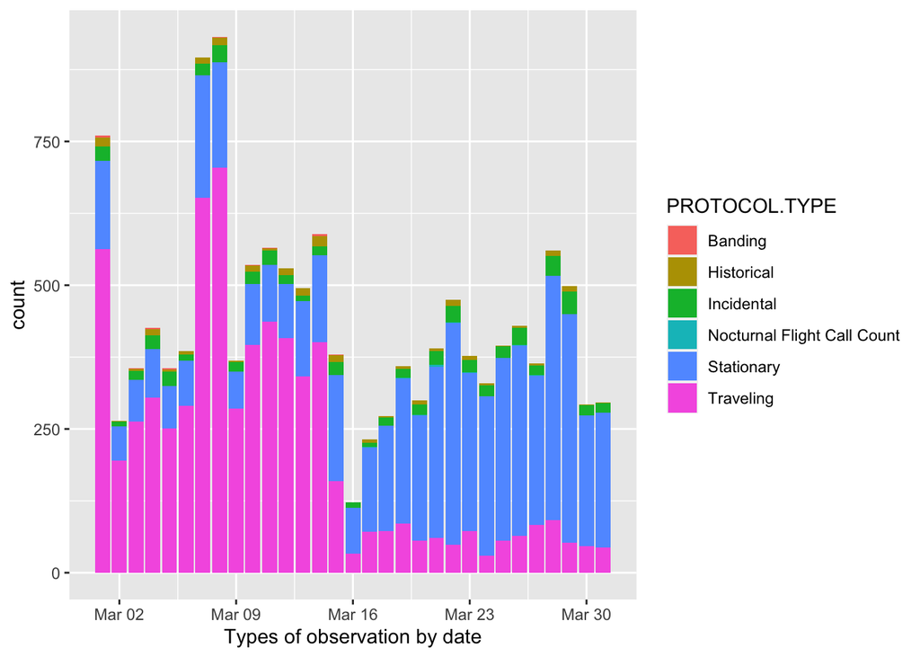

```r
spain_march <- spain %>% filter(month(date) == 03)

ggplot(spain_march, aes(x=date)) +
  geom_bar(aes(fill=PROTOCOL.TYPE)) +
  labs(x = "Types of observation by date")
```

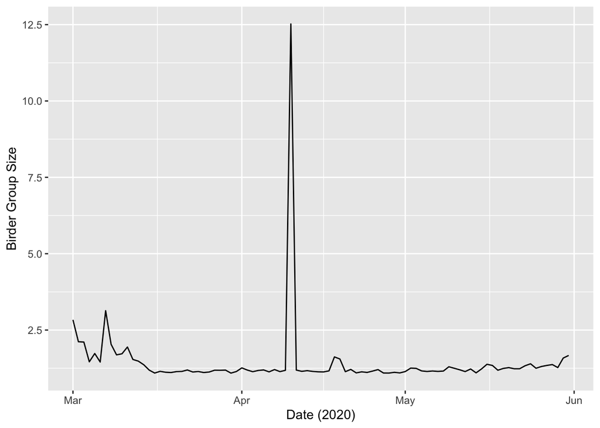

```r
avgs_birder_group <- spain %>%
  group_by(date) %>%
  summarize(average_group = mean(NUMBER.OBSERVERS, na.rm = TRUE))

ggplot(avgs_birder_group, aes(x=date, y=average_group)) +
  geom_line() +
  ylab("Birder Group Size") +
  xlab("Date (2020)")
```

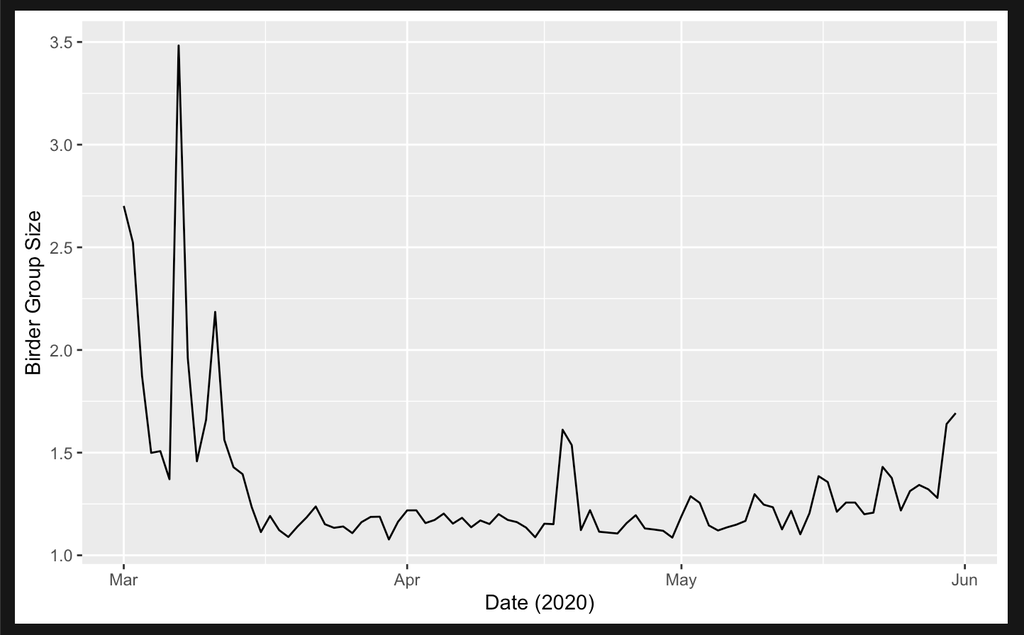

Screenshot of the line graph showing average birder size.

Finally, I wanted to map the types of birding events to see if any spatial patterns were immediately obvious. Since I’m really only interested in stationary and traveling events, I grouped all the remaining values as “Other” before mapping. These maps make it especially clear that most birding was stationary in April, although the “Traveling” event type increased again by May.

```r
not_needed <- c("Area", "Banding", "eBird Pelagic Protocol", "Historical", "Incidental", "Nocturnal Flight Call Count")

spain_sf$PROTOCOL.TYPE[spain_sf$PROTOCOL.TYPE %in% not_needed] <- "Other"

spain_sf_march <- spain_sf %>% filter(month(date) == 03)
spain_sf_april <- spain_sf %>% filter(month(date) == 04)
spain_sf_may <- spain_sf %>% filter(month(date) == 05)
```

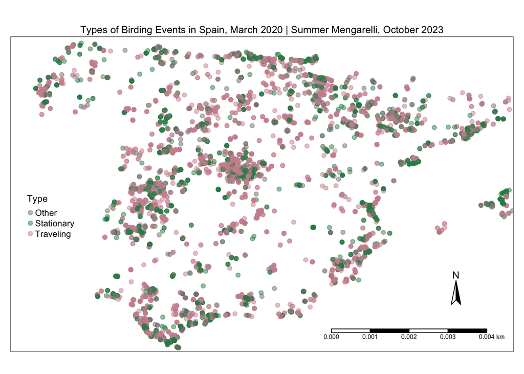

```r
type_palette <- c("#808080", "seagreen", "pink3")

### using bbox to get around not being able to filter out the island groups

tm_shape(spain_sf_march,
         bbox=c(-9.39288367353, 35.946850084, 3.03948408368, 43.7483377142),
         is.main=TRUE) +
  tm_dots(col= "PROTOCOL.TYPE",
          size = 0.15,
          palette = type_palette,
          title = "Type",
          shape=19,
          alpha=.5) +
  tm_layout(main.title = "Types of Birding Events in Spain, March 2020 | Summer Mengarelli, October 2023",
            main.title.size = 0.8, legend.title.size = 0.9, main.title.position = "center", legend.position=c(.03,.35)) +
  tm_scale_bar(position = c("right", "bottom")) +
  tm_compass(position = c(0.85, 0.15))
```

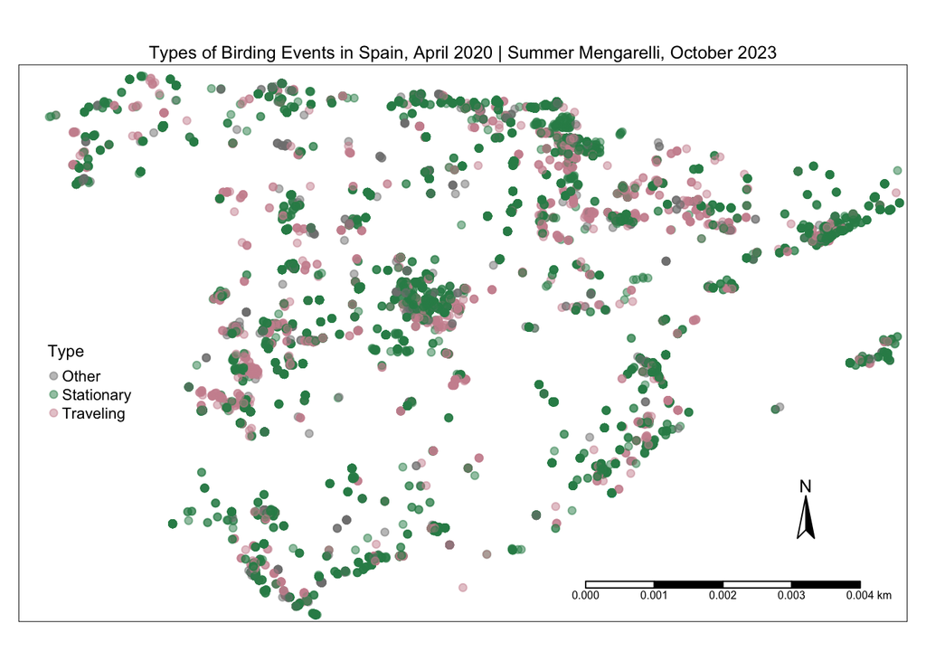

```r
tm_shape(spain_sf_april,
         bbox=c(-9.39288367353, 35.946850084, 3.03948408368, 43.7483377142),
         is.main=TRUE) +
  tm_dots(col= "PROTOCOL.TYPE",
          size = 0.15,
          palette = type_palette,
          title = "Type",
          shape=19,
          alpha=.5) +
  tm_layout(main.title = "Types of Birding Events in Spain, April 2020 | Summer Mengarelli, October 2023",
            main.title.size = 0.8, legend.title.size = 0.9, main.title.position = "center", legend.position=c(.03,.35)) +
  tm_scale_bar(position = c("right", "bottom")) +
  tm_compass(position = c(0.85, 0.15))
```

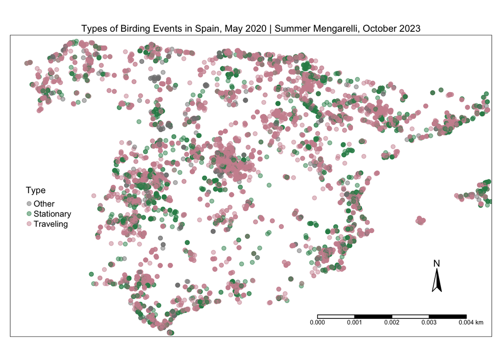

```r
tm_shape(spain_sf_may,
         bbox=c(-9.39288367353, 35.946850084, 3.03948408368, 43.7483377142),
         is.main=TRUE) +
  tm_dots(col= "PROTOCOL.TYPE",
          size = 0.15,
          palette = type_palette,
          title = "Type",
          shape=19,
          alpha=.5) +
  tm_layout(main.title = "Types of Birding Events in Spain, May 2020 | Summer Mengarelli, October 2023",
            main.title.size = 0.8, legend.title.size = 0.9, main.title.position = "center", legend.position=c(.03,.35)) +
  tm_scale_bar(position = c("right", "bottom")) +
  tm_compass(position = c(0.85, 0.15))
```

#### References

Cué, C. E. (2020, March 13). Sánchez decreta el estado de alarma durante 15 días. El País. https://elpais.com/espana/2020-03-13/el-gobierno-debate-decretar-el-estado-de-alarma.html

Marcos, J. (2020, March 28). Paralizada toda actividad no esencial en España. El País. https://elpais.com/espana/2020-03-28/el-gobierno-amplia-el-confinamiento-los-trabajadores-de-actividades-no-esenciales-deberan-quedarse-en-casa.html

Agencia Estatal Boletín Oficial del Estado. (2020, March 14). “Real Decreto 463/2020, de 14 de marzo, por el que se declara el estado de alarma para la gestión de la situación de crisis sanitaria ocasionada por el COVID-19” (PDF). Boletín Oficial del Estado (67): 25390–25400. ISSN 0212-033X. https://www.boe.es/boe/dias/2020/03/14/pdfs/BOE-A-2020-3692.pdf